# PaperNA’s

Adaline Powell

2024-04-29

## Missingness

In this analyiss, I confront the challenge of missing data within my dataset and explore methods to address it. Missing data can compromise the integrity of our analyses, but understanding the nature of missingness is crucial for selecting appropriate strategies.

Missing data can occur for various reasons, classified into three main categories: missing completely at random (MCAR), missing at random (MAR), and missing not at random (MNAR). In MCAR, the missingness is unrelated to the observed or unobserved data, representing a random process. MAR occurs when the probability of missingness depends on observed data but not on unobserved data. This means we can use available information to understand why data is missing. In contrast, MNAR suggests that the missingness is related to unobserved data, making it more challenging to address as the reasons for missingness are not easily discernible.

In this analysis, I address the issue of missing data within the ANES 2016 dataset while investigating the effect of skin tone on various socio-political variables and personal characteristics. I will examine the prevalence and patterns of missingness across variables such as skin tone, feminist support, voting behavior, party identification, and personal characteristics like gender, education, and marital status.

### What is missing in the cleans ANES 2016 data set?

#### Why is there missinging

The question we must now address is: why do we observe missingness in our dataset? Specifically, why do we encounter a significant number of empty values for the skin tone variable, considering its crucial importance for this analysis?

To further investigate this issue, I incorporated the mode of interviews conducted in the ANES survey, which includes both face-to-face and web-based interviews. In the face-to-face interviews, interviewers were trained to accurately assess respondents’ skin tone using a standardized scale. However, web-based surveys lacked this opportunity for assessment by trained interviewers.

This leads us to speculate that the mode of interview may be a contributing factor to the missingness observed in the skin tone variable. Missingness appears to be related to the mode of interview, and this information is readily available in our dataset for further exploration.

Given this understanding, it seems plausible to conclude that missingness in the skin tone variable may be at random, as it is associated with the mode of interview, a known variable in our dataset. With this insight, employing a machine learning model for imputation could potentially offer the most effective approach to handle missing data under this variable, leveraging available information to accurately predict missing values.

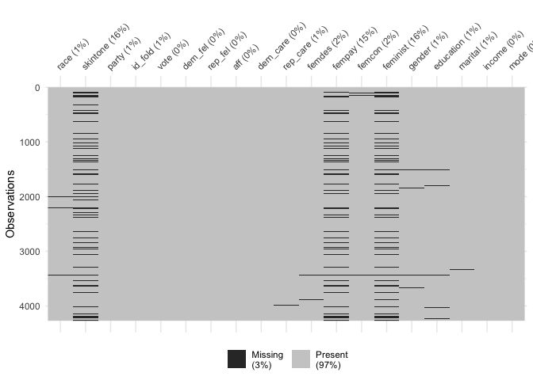

```
##      race  skintone     party   id_fold      vote   dem_fel   rep_fel       aff
##        33       693        25        23        16         0         0         0
##  dem_care  rep_care    femdes    fempay    femcon  feminist    gender education
##        18        24        76       632        78       696        52        44
##   marital    income      mode
##        27         0         0
```

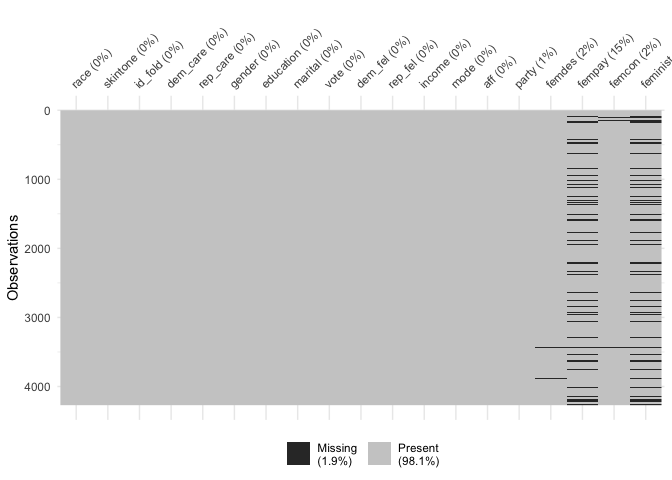

### Comparing listwise deletion with missForest imputation

We now turn to assessing the performance of machine learning imputation and listwise deletion in handling missing data. The tables below compare the two methods, focusing on the relationship between skin tone and voting probability in the first table, and the relationship between skin tone and feminist support in the second.

Firstly, examining the voting probability, both models seem to perform similarly, with estimates not deviating significantly from each other. However, one notable difference lies in the impact of missing values. When missing values are imputed, the difference in voting probability between medium skin tone (skin tone two) and skin tone three is notably greater compared to listwise deletion. Additionally, with imputed missing values, education emerges as statistically significant.

Turning to the analysis of feminist support, the estimates between the two methods are nearly identical. However, similar to the voting probability analysis, education is statistically significant in the imputed dataset.

Table 1: Voting

|  | Listwise |  |  | Imputated |  |  |
| --- | --- | --- | --- | --- | --- | --- |
| Predictors | Odds Ratios | CI | p | Odds Ratios | CI | p |
| {Intercept} | 3.78 | 0.38 – 92.80 | 0.308 | 2.14 | 0.33 – 20.31 | 0.459 |
| Skintone[2] | 1.14 | 0.27 – 4.14 | 0.851 | 1.08 | 0.26 – 3.94 | 0.906 |
| Skintone[3] | 0.88 | 0.19 – 3.82 | 0.871 | 1.58 | 0.35 – 6.38 | 0.530 |
| Gender[Female] | 4.70 | 0.90 – 25.12 | 0.062 | 4.83 | 0.92 – 26.03 | 0.059 |
| Income [Q2] | 0.33 | 0.02 – 2.25 | 0.329 | 0.53 | 0.08 – 2.21 | 0.438 |
| Income[Q3] | 0.64 | 0.03 – 4.65 | 0.700 | 1.21 | 0.17 – 5.35 | 0.820 |
| Income[Q4] | 0.99 | 0.05 – 8.32 | 0.993 | 1.85 | 0.25 – 9.32 | 0.486 |
| Education | 2.09 | 0.93 – 5.16 | 0.088 | 2.31 | 1.10 – 5.38 | **0.037** |
| Skintone[2]:Female | 0.49 | 0.08 – 2.89 | 0.427 | 0.51 | 0.09 – 2.98 | 0.450 |
| Skintone[3]:Female | 0.76 | 0.08 – 7.47 | 0.807 | 0.55 | 0.07 – 4.22 | 0.556 |
| Observations | 327 |  |  | 402 |  |  |
| R<sup>2</sup> Tjur | 0.091 |  |  | 0.091 |  |  |

Table 2: Feminism

|  | Listwise |  |  | Imputated |  |  |
| --- | --- | --- | --- | --- | --- | --- |
| Predictors | Estimates | CI | p | Estimates | CI | p |
| {Intercept} | 0.60 | 0.47 – 0.74 | **<0.001** | 0.61 | 0.49 – 0.73 | **<0.001** |
| Skintone[2] | -0.04 | -0.11 – 0.04 | 0.356 | -0.04 | -0.11 – 0.04 | 0.333 |
| Skintone[3] | -0.04 | -0.13 – 0.04 | 0.341 | -0.04 | -0.13 – 0.04 | 0.327 |
| Gender[Female] | 0.03 | -0.05 – 0.12 | 0.411 | 0.03 | -0.05 – 0.11 | 0.430 |
| Income [Q2] | 0.03 | -0.08 – 0.15 | 0.571 | 0.03 | -0.07 – 0.13 | 0.560 |
| Income[Q3] | -0.01 | -0.12 – 0.11 | 0.922 | -0.01 | -0.11 – 0.09 | 0.821 |
| Income[Q4] | 0.01 | -0.10 – 0.13 | 0.806 | 0.01 | -0.09 – 0.11 | 0.911 |
| Education | 0.03 | -0.00 – 0.07 | 0.071 | 0.04 | 0.00 – 0.07 | **0.031** |
| Skintone[2]:Female | 0.01 | -0.08 – 0.10 | 0.860 | 0.01 | -0.08 – 0.10 | 0.813 |
| Skintone[3]:Female | -0.04 | -0.15 – 0.08 | 0.528 | -0.02 | -0.13 – 0.09 | 0.693 |
| Observations | 324 |  |  | 339 |  |  |
| R<sup>2</sup> / R<sup>2</sup> adjusted | 0.073 / 0.046 |  |  | 0.076 / 0.051 |  |  |

Below provides a graphic of models assessing party. Similar to voting probability, the imputated data set clarifies the pattern. Furthermore the relationship appears more linear compared to the listwise deletion.

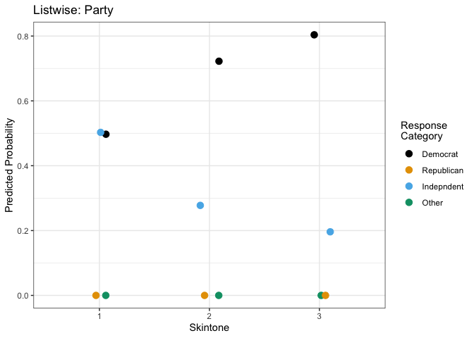

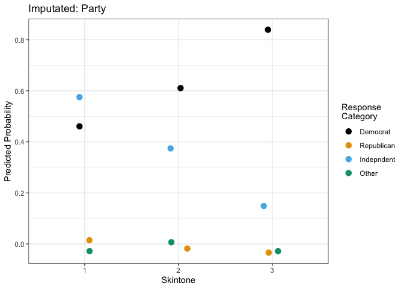

#### Voting

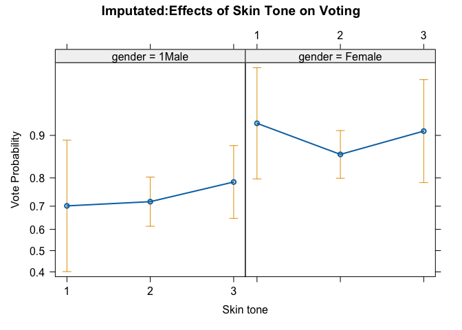

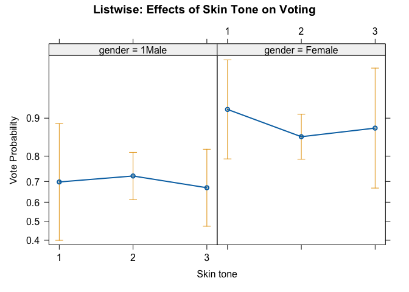

#### Party

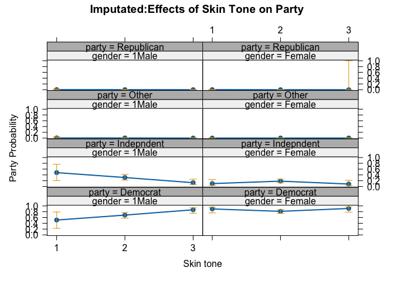

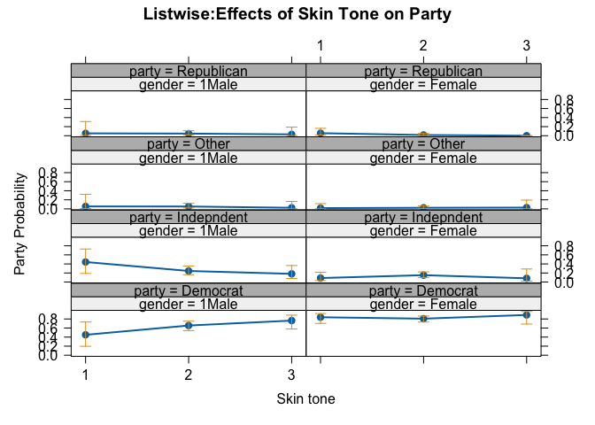

#### Feminist

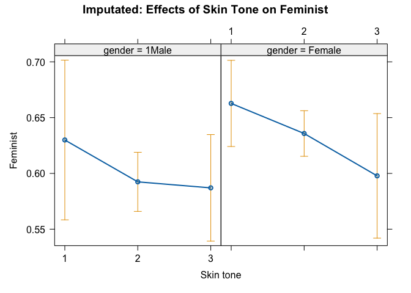

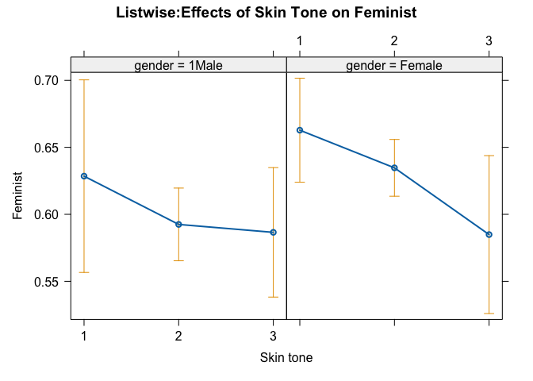

## Conclusion

It is difficult to conclude which method provided the closest results to reality because the estimates from both models were so similar. I believe further research, with better data, may benefit more from MissForest, as long as the researcher is aware of the cause of missingness.